# Chronic Kidney disease dataset

# The below plot is used ot check the randomness in the residuals for the new regression model

# The below we are also plotting residual vs fitted values

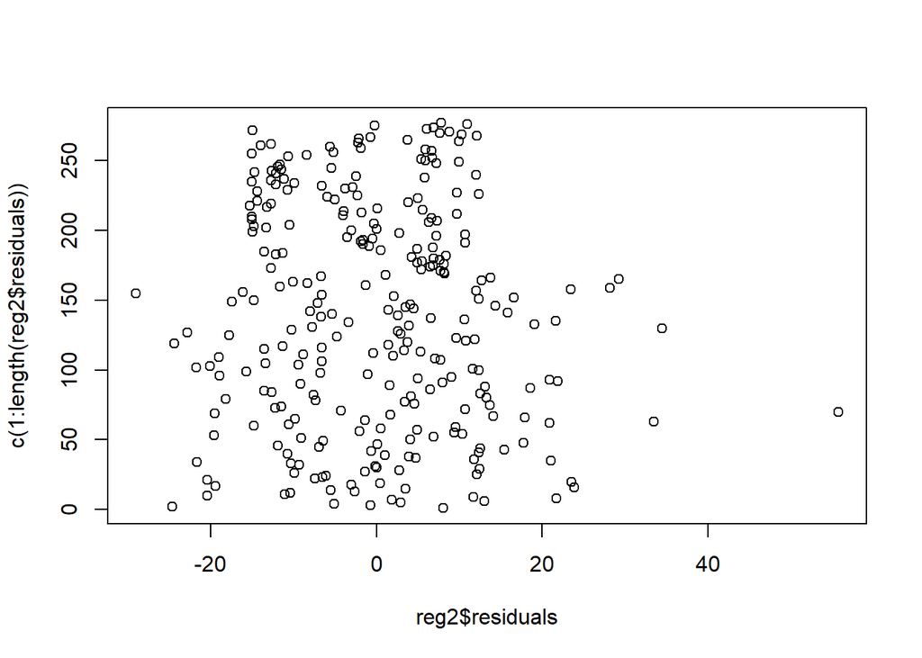

```r
plot(reg2$residuals, c(1:length(reg2$residuals)))
```

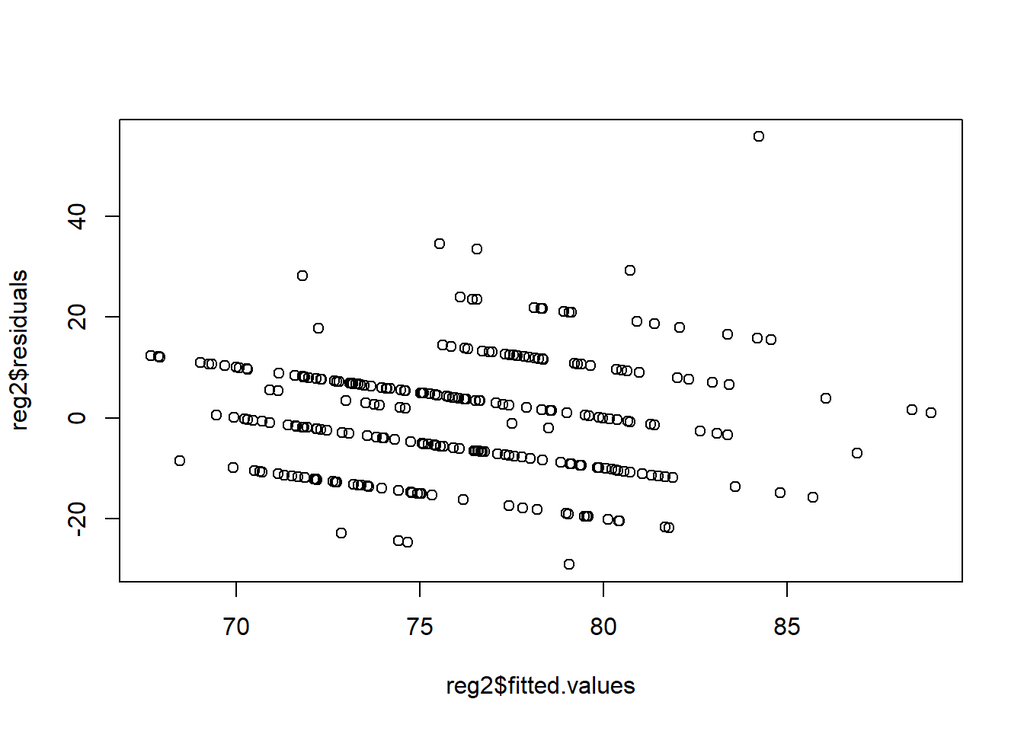

```r
plot(reg2$fitted.values, reg2$residuals)
```

# The below we are checking for Homoscadasticity and heteroscadasticity ##ho = data is homoscadisticity ##h1 = data is hetroscadisticity ## Here we perform bptest for checking the above hypothesis ## As here p-value < 0.05 reject the null hypothesis

```r
library(lmtest)
bptest(reg2)
```

```
##
##  studentized Breusch-Pagan test
##
## data:  reg2
## BP = 18.803, df = 7, p-value = 0.008827
```

# If there is more common varience (common elements) then there will be less proper output

# For doing this multicolinearity we need to install CAR library

# If vif is < 2.5 it is small model saying that there is no multi colinearity problem or no problem

# If vif is < 4 it is small model saying that there is no mmulti colinearity problem or no problem

# As the values are with range there is less/no multi colinearity problem

```r
library(car)
vif(reg2)
```

```
##  datatrain$age   datatrain$bu  datatrain$pot  datatrain$sod   datatrain$sc
##       1.072671       2.288395       1.283792       1.315097       1.720227
## datatrain$hemo  datatrain$bgr
##       1.760140       1.137247
```

# Checking the normality of error terms

# error = actual - predicted

# For checking normality we do shapiro test, qqnorm, boxplot, histogram

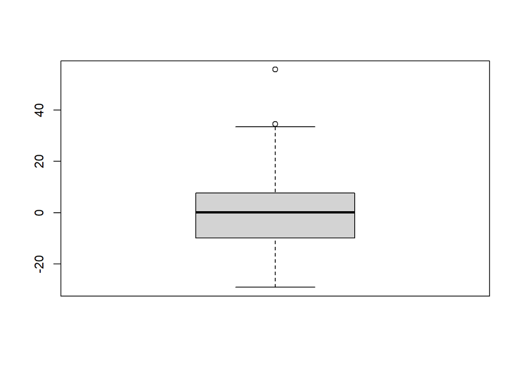

```r
boxplot(reg2$residuals)
```

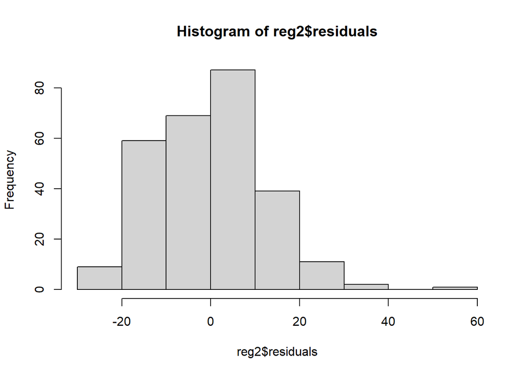

```r
hist(reg2$residuals)
```